# ZADANIE DOMOWE 3

Kacper Skonieczka

Listopad 20, 2021

# Opis ekperymentu

Przeprowadzony eksperyment miał potwierdzić to o czym mówimy na wykładzie- wyższość wykresów słupkowych nad kołowymi wykresami 3D. Sprawdziłem też czy poprawiony wykres z zadania domowego numer 2 podoba się bardziej od pierwowzoru ludziom, którzy nie są bezpośrednio związani z wizualizacją danych. Wykresy dostosowałem do bezpłatnego narzędzia google forms, powiększając czcionkę napisów, by wypełnianie przygotowanej ankiety na której opierał się eksperyment było przyjemne zarówno z komputera jak i telefonu. Danych użyłem tych samych co w zadaniu domowym numer 2:

#### Na kogo zagłosowałbyś w wyborach?

[output not shown]

Wykorzystane wykresy w części pierwszej:

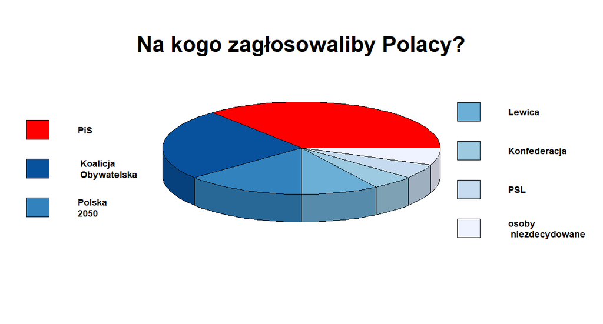

Wykres 1

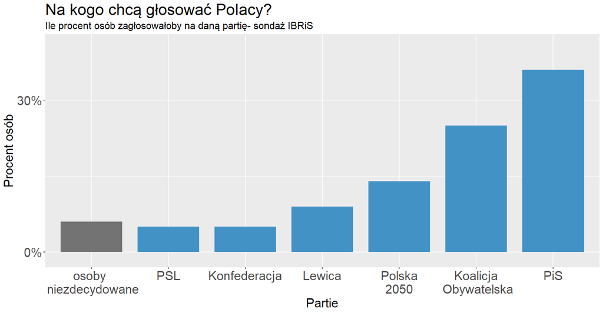

Wykres 2

Pierwsza cześć eksperymentu polegała zatem na zadaniu pytań o to samo do wykresu 1.:

1. Jaki procent koła zajmuję czerwona część?
2. Ile Polaków zagłosowałoby na Koalicję Obywatelską?
3. Czy na Koalicję i Polskę 2050 zagłosowałoby razem więcej osób niż na PiS?

i wykresu 2.:

1. Ile procent Polaków zagłosowałoby na PiS?
2. Ile Polaków zagłosowałoby na Koalicję Obywatelską?
3. Czy na Koalicję Obywatelską i Polskę 2050 razem zagłosowałoby więcej osób niż na Pis?

Wszystkie pytania były zamknięte, a podane możliwości odpowiedzi te same. Na wykresie kołowym (nr 1) wiemy, że całe koło to 100%, stąd na moim wykresie słupkowym (nr 2) również postanowiłem zaznaczyć tylko jedną wartość (oprócz 0%), żeby porównywanie łatwości odczytu i porównywania wartości było jak najbardziej rzetelne.

Wykorzystane wykresy w części drugiej:

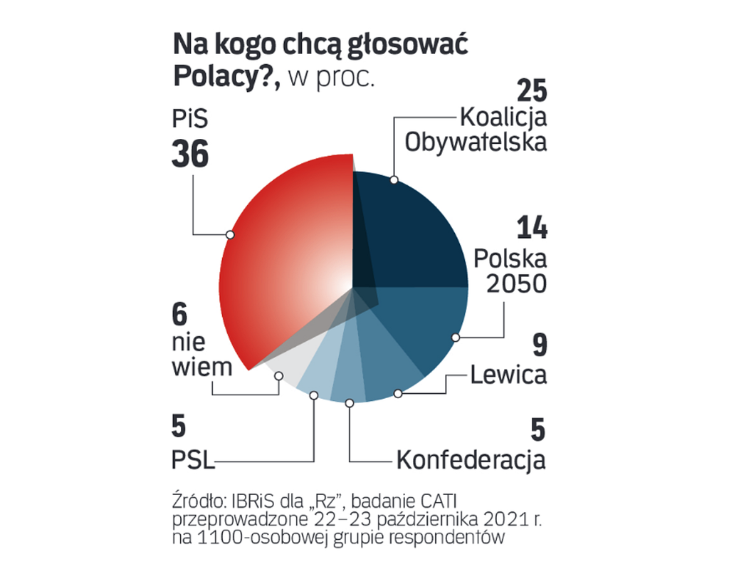

Wykres 3

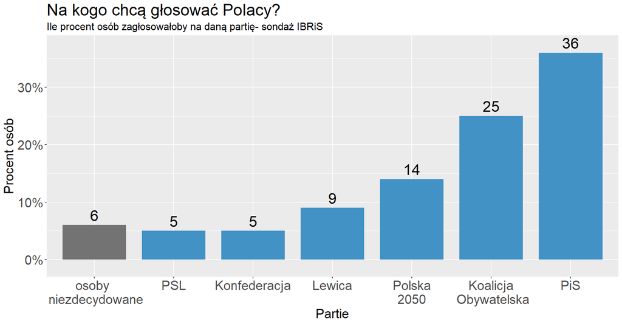

Wykres 4

Druga część eksperymentu polegała na ocenieniu wykresów numer 3 i 4 w skali od 1 do 5, i możliwości podania przyczyny, jeśli któryś podobał się komuś bardziej.

Ankietę wypełniło 19 osób. Głównie byli to studenci politechnik, nikt nie był bezpośrednio związany z wizualizacją danych. Ankieta była podzielona na sekcje, a ankietowani zostali poproszeni o nie wracanie do tych już wypełnionych. W ten sposób w części pierwszej uczestnicy widzieli tylko jeden wykres, do którego mieli pytania i nie mogli sugerować się drugim.

# Opracowanie wyników części pierwszej

Wykres wyników dla pytania pierwszego prezentuje się tak:

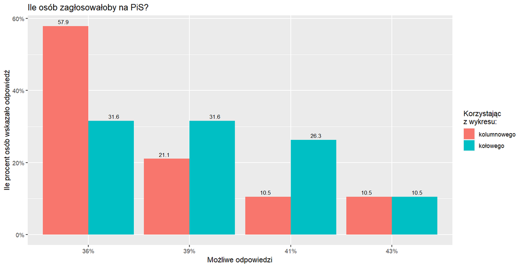

Wykres wyników dla pytania 1.

Prawidłowa odpowiedzią było 36%. Korzystając z wykresu kolumnowego aż 25% osób więcej potrafiło wskazać prawidłową wartość. Należy pamiętać, że ankietowani podeszli do ankiety bez stresu, że zaznaczą złą odpowiedź, więc zaznaczali pierwszą wartość jaka im pasowała “na oko”. Zatem taka różnica już pokazuję, że wybrany wykres ma duże znaczenie. Warto też zwrócić uwagę, na złe odpowiedzi. Przy wykresie słupkowym większość błędnych odpowiedzi to te wskazujące na 39%, czyli blisko prawidłowej wartości. Przy wykresie kołowym większa część stanowi suma odpowiedzi 41% i 43%. Myślę, że może to mieć duży związek z iluzją która otrzymujemy korzystając z wykresu 3D.

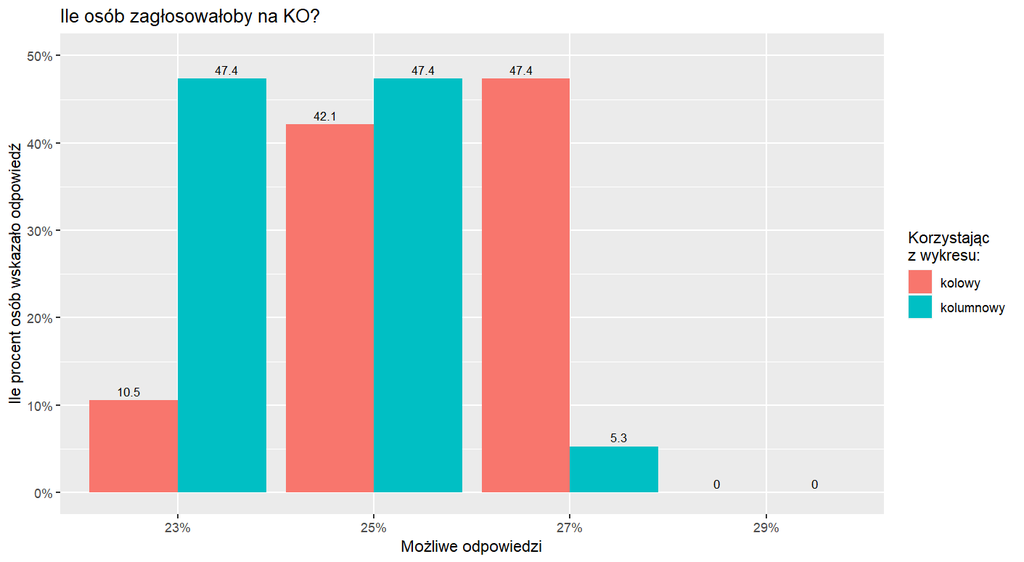

Wykres wyników dla pytania 2.

To pytanie okazało się podobnie trudne bez względu na wykres. Warto zwrócić jednak uwagę, że przy wykresie kolumnowym ludzie mieli tendencję do zaniżania wartości, a przy wykresie kolumnowym zawyżania, co miało miejsce już przy poprzednim pytaniu. Wyciągnąłbym wniosek, że ilość oznaczonych współrzędnych na skali ma znaczenie. W tym przypadku jedna nie wystarczyła, żeby wykres kolumnowy okazał się znacząco lepszy od wykresu kołowego, jeśli chodzi o dokładne odczytywanie wyników. Zatem gdy korzystamy z wykresu słupkowego wychodzi nam ono lepiej (jak w pytaniu 1.) bądź na tym samym poziomie- przy takich typach wykresów jak w eksperymencie.

Sprawdźmy, jak wygląda porównywanie wartości, czyli co odpowiedziały osoby korzystając z różnych typów wykresu na pytanie numer 3 z części 1.

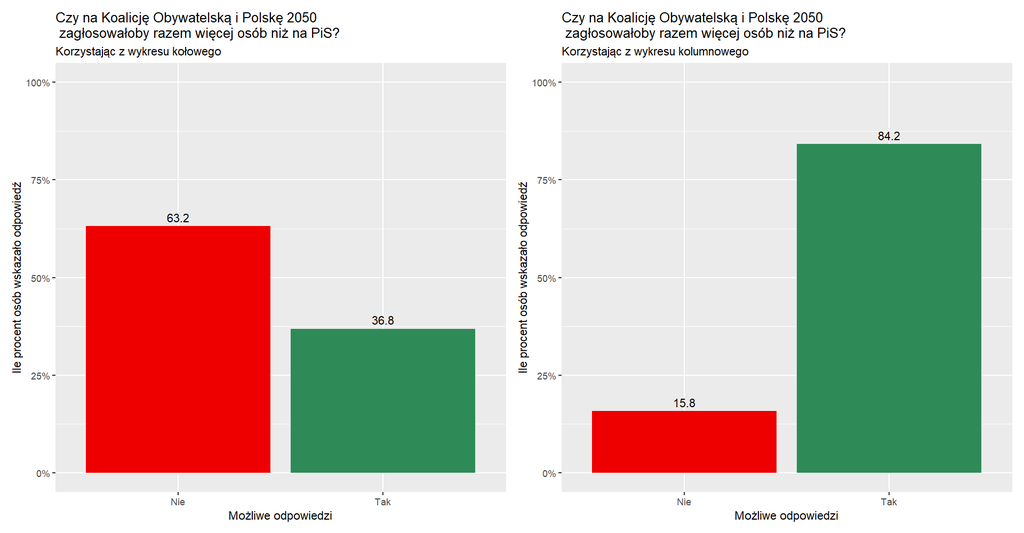

Wykresy wyników dla pytania 3.

Właściwą odpowiedzią było tak. Widzimy, że korzystając z wykresu kołowego 3D ponad połowa osób źle porównała części koła. Natomiast tylko niewielka część się pomyliła mając do dyspozycji wykres słupkowy. Porównywanie długości idzie zatem ludziom znacznie lepiej niż porównywanie kątów. 50% różnica poprawnych odpowiedzi jednoznacznie wskazuję, że prosty wykres kolumnowy lepiej nadaję się do wizualizacji danych.

# Opracowanie wyników części drugiej

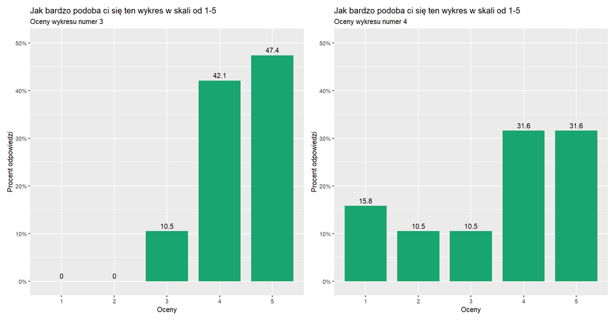

Wizualizacja wyników części 2.

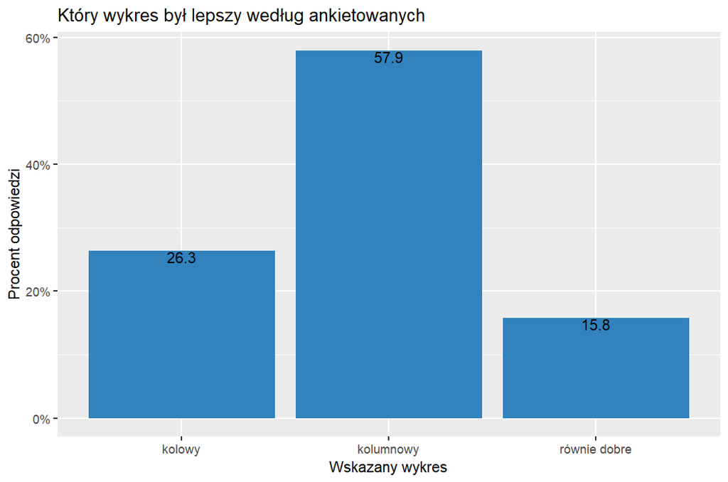

Wykres podsumowujący drugą części eksperymentu

#### Powody dlaczego bardziej podobał się wykres kolumnowy:

| Odpowiedzi | Ilość takich odpowiedzi |
| --- | --- |
| Jest czytelniejszy | 3 |
| Lubię wykresy słupkowe, wyglądał profesjonalniej | 3 |
| Lubię wykresy słupkowe | 3 |
| Miał ładniejsze kolorki | 1 |
| Słupkowy jest czytelniejszy, bardziej estetyczny | 1 |

| Odpowiedzi | Ilość takich odpowiedzi |
| --- | --- |
| Lubię wykresy kołowe | 1 |
| Lubię wykresy kołowe, miał ładniejsze kolorki, wyglądał na trudniejszy do stworzenia | 1 |
| Lubię wykresy kołowe, wyglądał profesjonalnie | 2 |

# Podsumowanie

Eksperyment udowodnił, że proste wykresy kolumnowe są lepsze od kołowych z dodatkowymi efektami. Ich główna zaletą jest czytelność, a przecież o to chodzi w wizualizacji danych. Te których nie możemy odczytać stają się bezużyteczne. Stąd też, jak pokazują wyniki pytania 1. i 3., powinniśmy zapomnieć o wykresach 3D. Iluzje mogą znacznie obniżyć prawidłowość odczytu. Dodatkowo wyniki pytania 2. pokazały, że i te kolumnowe mogą być niedopracowane, w tym przypadku w dość “ekstremalny” sposób. Myślę, że możemy z pewnością stwierdzić, że zaznaczenie dodatkowych wartości na osi y na wykresie numer 2. znacznie ułatwiłoby precyzyjne odczytywanie danych. Zważając na otrzymane wyniki, powinniśmy zawsze pamiętać o zaznaczeniu ich odpowiedniej ilości na osiach. Jeżeli nasz celem jest ukazanie proporcjonalnej różnicy wartości, to należy wziąć pod uwagę wykres kolumnowy, ponieważ porównywanie długości kolumn okazało się proste.